# traveltime - a Traveltime API Wrapper for R

# 3 Plotting a Traveltime-Map (ggmap & ggplot2)

With the latest version of ggplot2, `geom_sf` has been introduced, which allows to plot geodata stored in dataframes with class sf very conveniently. Let’s retrieve isochrones for four different travel modes and compare how far you can go by foot, bike, car or public transport within half an hour.

```r
# with purrr::map we can easily retrieve isochornes for different timespans


traveltimes <-c("walking","cycling","driving","public_transport") %>%
  map(.,~traveltime_map(appId="YourAppId",
                        apiKey="YourApiKey",
                        location=c(47.37787,8.54045),
                        traveltime=1800,
                        type=.x,
                        departure="2018-11-15T08:00:00+01:00") %>%
        mutate(mode=.x))

# map_dfr does not work well with sf objects (yet?) so we just..

# ... rbind the dataframes toghether via do.call
df<-do.call(rbind.data.frame, traveltimes)
```

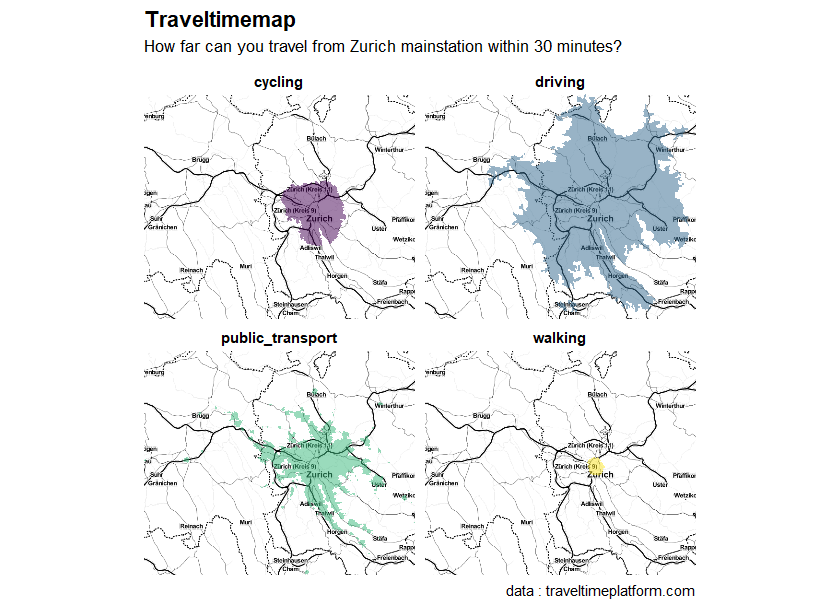

```r
library(ggmap)

#get basemap with ggmap
basemap <- get_stamenmap(bbox = unname(st_bbox(traveltimes)),maptype = "toner-hybrid")

#plot
ggmap(basemap)+
  geom_sf(data=traveltimes,inherit.aes = FALSE, aes(fill=mode), alpha=0.5,color=NA)+
  scale_fill_viridis_d()+
  theme_void()+
  coord_sf(datum = NA)+
  facet_wrap(~mode)+
  guides(fill="none")+
  theme(plot.title=element_text(face="bold"),
        plot.subtitle=element_text(size = 10, margin=margin(t=5, b = 10)),
        strip.text=element_text(face="bold",margin=margin(b = 4)))+
  labs(title="Traveltimemap", subtitle="How far can you travel from Zurich mainstation within 30 minutes?",         caption="data : traveltimeplatform.com")
```

# 4 Creating an animated Map with gganimate : Rush Hour VS Night Time Drive

How far can you drive within 30min from Zurich at 7AM vs 11PM? An animated map unveils the difference in range impressively.

```r
library(gganimate)
library(traveltime)
library(tidyverse)
library(sf)
```

We can call the traveltime-API to get the isochrones for several departure-times. We could do the same for different modes of transport, locations and traveltime. With `purrr::map` we can pass vectors of elements to the `traveltime_map`- function to do so.

```r
traveltimes <- c("2018-11-12T07:00:00+01:00","2018-11-12T23:00:00+01:00") %>%
  map(.,~traveltime_map(appId="YourAppId",
                        apiKey="YourApiKey",
                        location=c(47.378610,8.54000),
                        traveltime=1800,
                        type="driving",
                        departure=.x) %>% mutate(time=.x))

animationdf <-do.call(rbind, traveltimes)
```

Just with a few lines of extra code we can turn a static map into an animated one with gganimate!

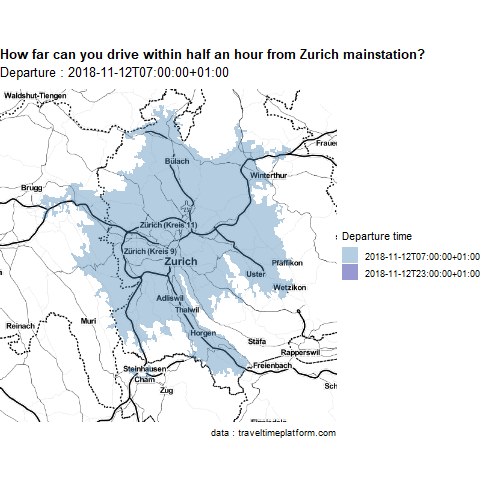

```r
#get basemap with ggmap
basemap <- get_stamenmap(bbox = unname(st_bbox(animationdf)),maptype = "toner-hybrid")

#just a few lines to trigger gganimate!
animation <- ggmap(basemap)+
  geom_sf(data = animationdf, aes(group=type,fill=departure),inherit.aes = FALSE, alpha=0.4, colour=NA)  +
  theme_void()+
  theme(plot.title=element_text(face="bold"),
        plot.subtitle=element_text(size = 13, margin=margin(t=5, b = 10)))+
  coord_sf(datum = NA)+
  transition_states(state, 2, 1)+
  scale_fill_manual(name="Departure time", values = c("steelblue", "darkblue"))+
  labs(title = 'How far can you drive within half an hour from Zurich mainstation?', subtitle='Departure : {closest_state}',caption="data : traveltimeplatform.com")

animation

#save the animated map as .gif
# anim_save("traveltime.gif")
```